# Regression: predictive modelling – Part 1

ENVX2001 - Applied Statistical Methods

Liana Pozza

The University of Sydney

May 2024

# Predictive modelling

> “The best way to predict the future is to create it.”

– Peter Ferdinand Drucker, 1909–2005

# Our workflow so far

## Workflow

1. Model development
   - **Explore**: visualise, summarise
   - **Transform predictors**: linearise, reduce skewness/leverage
   - **Model**: fit, check assumptions, interpret, transform. Repeat.
2. Variable selection
   - **VIF**: remove predictors with high variance inflation factor
   - **Model selection**: stepwise selection, AIC, principle of parsimony, assumption checks
3. **Predictive modelling**
   - **Predict**: Use the model to predict new data
   - **Validate**: Evaluate the model’s performance

# Making predictions

## Previously on ENVX2001…

We fitted a multiple linear regression model to the data.

```r
library(tidyverse)
multi_fit <- lm(log(Ozone) ~ Temp + Solar.R + Wind, data = airquality)
summary(multi_fit)
```

```
Call:
lm(formula = log(Ozone) ~ Temp + Solar.R + Wind, data = airquality)

Residuals:
     Min       1Q   Median       3Q      Max
-2.06193 -0.29970 -0.00231  0.30756  1.23578

Coefficients:
              Estimate Std. Error t value Pr(>|t|)
(Intercept) -0.2621323  0.5535669  -0.474 0.636798
Temp         0.0491711  0.0060875   8.077 1.07e-12 ***
Solar.R      0.0025152  0.0005567   4.518 1.62e-05 ***
Wind        -0.0615625  0.0157130  -3.918 0.000158 ***
---
Signif. codes:  0 '***' 0.001 '**' 0.01 '*' 0.05 '.' 0.1 ' ' 1

Residual standard error: 0.5086 on 107 degrees of freedom
  (42 observations deleted due to missingness)
Multiple R-squared:  0.6644,    Adjusted R-squared:  0.655
F-statistic: 70.62 on 3 and 107 DF,  p-value: < 2.2e-16
```

$$\widehat{log(Ozone)}=-0.262 + 0.0492 \cdot Temp + 0.00252 \cdot Solar.R - 0.0616 \cdot Wind$$

## Predict: equation

$$\widehat{log(Ozone)}=-0.262 + \color{darkorchid}{0.0492} \cdot Temp + \color{darkorange}{0.00252} \cdot Solar.R - \color{seagreen}{0.0616} \cdot Wind$$

On a certain day, we measured (*units are Imperial*):

- temperature `Temp` to be 80 degrees Fahrenheit
- solar radiation `Solar.R` to be 145 units (Langleys)
- wind speed `Wind` to be 10.9 miles per hour

**What is the predicted ozone level?** . . .

$$\widehat{log(Ozone)}= -0.262 + \color{darkorchid}{0.0492 \cdot 80} + \color{darkorange}{0.00252 \cdot 145} - \color{seagreen}{0.0616 \cdot 10.9}$$

Easy! The two things we need to think about are…

- **What is the uncertainty in this prediction?**
- **Can this model be used to predict ozone if we collect new data in the future?**

## Uncertainty

- **Confidence interval**: uncertainty in the **mean** response at a given predictor value.
- **Prediction interval**: uncertainty in a **single** response at a given predictor value.

### What it means

> **95% confidence interval**: Given the parameters of the model, we are 95% confident that the *mean* response at a given predictor value is between $y_1$ and $y_2$.

> **95% prediction interval**: Given the parameters of the model, we are 95% confident that a *single* response at a given predictor value is between $y_1$ and $y_2$.

### Why the distinction?

- **Confidence interval**: we are interested in the *mean* response.
- **Prediction interval**: we are interested in a *single* value prediction.

## Confidence interval (CI)

### CI: standard error of the fit

$$se(\widehat{y}) = \sqrt{MSE \cdot \left( \frac{1}{n} + \frac{(x_0 - \bar{x})^2}{\sum_{i=1}^n (x_i - \bar{x})^2} \right)}$$
where $x_0$ is the predictor value at which we want to predict the response

- $MSE$ is the mean squared error of the fit (residual ms)
- $\sum_{i=1}^n (x_i - \bar{x})^2$ is the sum of squares of the predictor values
- $n$ is the number of observations
- $\bar{x}$ is the mean of the predictor values

## Prediction interval (PI)

### PI: standard error of the prediction

$$se(\widehat{y}) = \sqrt{MSE \cdot \left( 1 + \frac{1}{n} + \frac{(x_0 - \bar{x})^2}{\sum_{i=1}^n (x_i - \bar{x})^2} \right)}$$
where $x_0$ is the predictor value at which we want to predict the response

- $MSE$ is the mean squared error of the fit (residual ms)
- $\sum_{i=1}^n (x_i - \bar{x})^2$ is the sum of squares of the predictor values
- $n$ is the number of observations
- $\bar{x}$ is the mean of the predictor values

The only difference between the CI and PI is the additional term $1$ in the PI formula that is added. The reason for this is that we are interested in a *single* response, not the *mean* response.

## Predictions in R

- We can use the `predict()` function
- First, we need to create a new data frame with the predictor values we want to predict at

```r
to_predict <- data.frame(Temp = 80, Solar.R = 145, Wind = 10.9)
```

- Then, we can use the `predict()` function to predict the response at these values
- Use `interval = "confidence"` or `interval = "prediction"` to get the confidence or prediction interval.

```r
predict(multi_fit, newdata = to_predict, interval = "confidence")
```

```
       fit      lwr      upr
1 3.365227 3.246265 3.484189
```

```r
predict(multi_fit, newdata = to_predict, interval = "prediction")
```

```
       fit      lwr      upr
1 3.365227 2.350051 4.380404
```

## Comparing CI vs PI

- The confidence interval is narrower than the prediction interval.
- It’s easier to visualise two-dimensional data, so let’s look at a simple linear regression model of `log(Ozone)` vs. `Temp`.

```r
fit <- lm(log(Ozone) ~ Temp, data = airquality)
```

## Comparing CI vs PI

- We create a range of predictions across all possible `Temp` values in 0.1 °F increments, and calculate both the CI and PI for each of those values

```r
# Generate values to predict at in 0.1 degree increments
to_pred <- data.frame(Temp = seq(min(airquality$Temp), max(airquality$Temp), by = 0.1))
preds_ci <- predict(fit, newdata = to_pred, interval = "confidence") # confidence interval
preds_pi <- predict(fit, newdata = to_pred, interval = "prediction") # prediction interval
```

- Extract only upper and lower CI and PI values and merge the data frames

```r
pred_df <- data.frame(Temp = to_pred$Temp,
                      Lci = preds_ci[, "lwr"],
                      Uci = preds_ci[, "upr"],
                      Lpi = preds_pi[, "lwr"],
                      Upi = preds_pi[, "upr"])
```

## Visualising CI vs PI

```r
p <-
  ggplot(airquality, aes(Temp, log(Ozone))) +
  geom_point() +
  geom_line(data = pred_df, aes(Temp, Lci), color = "blue") +
  geom_line(data = pred_df, aes(Temp, Uci), color = "blue") +
  geom_line(data = pred_df, aes(Temp, Lpi), color = "red") +
  geom_line(data = pred_df, aes(Temp, Upi), color = "red") +
  labs(x = "Temperature (F)", y = "log(Ozone)") +
  theme_bw()
p
```

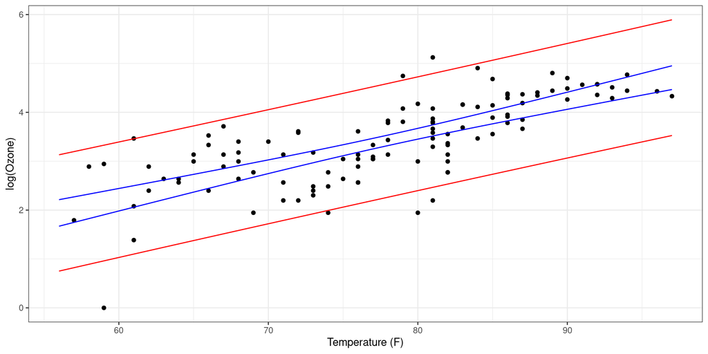

## CI and `geom_smooth()`

- Notice that `geom_smooth()` uses the CI, not the PI.

```r
p + geom_smooth(method = "lm", se = TRUE)
```

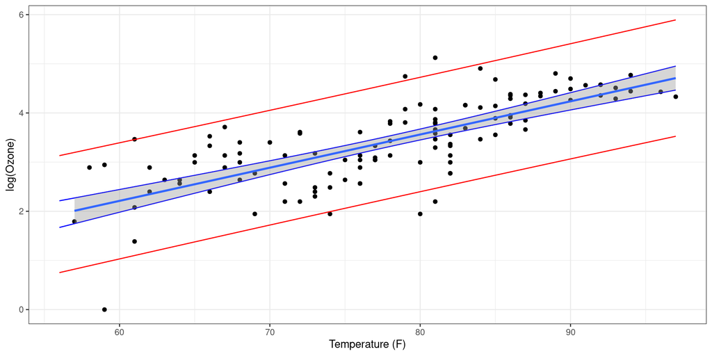

## Limitations

All is good when we want to assess uncertainty in a model that we have already fit. But what if we want to know how well the model predicts **new** data, i.e. data that we did not use to fit the model?

### What we need

- A way to estimate how well the model predicts new data *that hasn’t been used to fit the model*, i.e. an **independent** dataset.
- Because we have the **actual values** in the new dataset, we can compare them to the **predicted values** from the model.
  - If the model is good, we expect the predictions to be close to the actual values.
  - If the model is bad, we expect the predictions to be *far* from the actual values.

# Model validation

## General idea

- We have a dataset that we use to fit a model, and want to assess how well the model predicts new data by performing **model validation**.
- We can:
  - use the *same* dataset to assess how well the model fits the data (e.g. $r^2$); or
  - **use a *different* dataset to assess how well the model predicts new data (e.g. RMSE).**
- The dataset can be obtained by:
  - Collecting new data.
  - Splitting the existing data into two parts before model building.
  - Cross-validation or k-fold cross-validation of existing data.

## Collecting new data

Dataset

## Collecting new data

$+$

Dataset

New dataset

## Collecting new data

$+$

Dataset

New dataset

- The best way to assess how well a model predicts new data is to collect new data.
  - **Training set**: used to fit the model.
  - **Test set**: used to assess how well the model predicts new data.

## Collecting new data

### Pros

- The new data is completely independent of the data used to fit the model.
- Compared to splitting existing data, we have *more* data to fit the model and *more* data to validate the model.

### Cons

- It can be expensive and time-consuming to collect new data.
- Some data may be impossible to collect (e.g. historical data).

## Data splitting

Dataset

## Data splitting

Dataset

(Training)

Subset (Test)

## Data splitting

Dataset

(Training)

Subset (Test)

- Split the existing data into two parts:
  - **Training set**: used to fit the model.
  - **Test set**: used to assess how well the model predicts new data.

## Data splitting

### Pros

- The test set is completely independent of the training set.
- Compared to collecting new data, it is cheaper and faster to split existing data.

### Cons

- We have *less* data to fit the model and *less* data to validate the model.
- How do we split the data?

## Cross-validation

## Cross-validation

## Cross-validation

## Cross-validation

Iteration 1

Iteration 2

Iteration 3

And so on…

## Cross-validation

Iteration 1

Iteration 2

Iteration 3

And so on…

- Like data splitting, where existing data is split into two parts:
  - **Training set**: used to fit the model.
  - **Test set**: used to assess how well the model predicts new data.
- The **difference** is that the splitting is done *multiple* times, and the model is fit and validated *multiple* times.

## Cross-validation

### Pros

- Same as data splitting, but also:
  - The model is fit and validated *multiple* times, so we can get a better estimate of how well the model predicts new data.

### Cons

- We have *less* data to fit the model and *less* data to validate the model.
- It can be computationally expensive to perform cross-validation.

## *k*-fold cross-validation

## *k*-fold cross-validation

## *k*-fold cross-validation

## *k*-fold cross-validation

Iteration 1 Iteration 2 Iteration 3 3-fold cross-validation Fold 1 Fold 2 Fold 3

## *k*-fold cross-validation

Iteration 1 Iteration 2 Iteration 3 3-fold cross-validation Fold 1 Fold 2 Fold 3

- split data into *k* groups (folds)
- **Train** on *k-1* folds, **Test** on the remaining fold
- All folds are used for testing once

## *k*-fold cross-validation

### Pros

- Same as cross-validation, but also:
  - Better use of *all* available data
  - Greatly reduces overfitting as the model’s performance is not just a result of the particular way the data was split.

### Cons

- Computationally expensive, since all data is used for training and testing
- Bias in small datasets: each fold may contain too little data to provide a representative sample

# Assessing prediction quality

## Root-mean-square error (RMSE)

The **most common metric** for comparing the performance of regression models.
$$RMSE = \sqrt{\frac{1}{n}\sum_{i=1}^{n}(y_i - \hat{y}_i)^2}$$

> Approximately, the standard deviation of the residuals.
- A measure of **accuracy** for the model.
- Unlike $r^2$, RMSE is **not** a relative measure, but is scaled to the units of $y$.
- The smaller the RMSE, the better the model.

## Mean error (ME)

The average of the residuals.

$$ME = \frac{1}{n}\sum_{i=1}^{n}y_i - \hat{y}_i$$

> Averaged difference between the predicted and observed values.
- A measure of **bias** for the model.
- Also scaled to the units of $y$.
- Can be positive or negative to indicate over- or under-estimation.

## Lin’s concordance correlation coefficient (CCC)

A modification of Pearson’s correlation coefficient that takes into account the deviation of the observations from the identity line (i.e., the 45° line where the values of the two variables are equal).

$$CCC = \frac{2\text{Cov}(X,Y)}{\text{Var}(X) + \text{Var}(Y) + (\mu_X - \mu_Y)^2}$$

## CCC vs Pearson correlation coefficient

```r
library(tidyverse)

df <- tibble(y = seq(0, 100, 5),
  "45 degree line | CCC = 1" = seq(0, 100, 5)) %>%
  mutate("Location shift | CCC = 0.89" = `45 degree line | CCC = 1` - 15) %>%
  mutate("Scale shift | CCC = 0.52" = y / 2) %>%
  mutate("Location and scale shift | CCC = 0.67" = y * 2 - 20)

# pivot
df_long <- df %>%
  pivot_longer(-1, values_to = "x") %>%
  mutate(name = factor(name,
    levels = c("45 degree line | CCC = 1",
      "Location shift | CCC = 0.89",
      "Scale shift | CCC = 0.52",
      "Location and scale shift | CCC = 0.67")))

ggplot(df_long, aes(x, y)) +
  geom_abline(intercept = 0, slope = 1, size = 0.5, colour = "grey") +
  facet_wrap(~name) +
  geom_point() +
  xlim(0, 100) +
  labs(x = "", y = "") +
  theme_bw() +
  geom_blank()
```

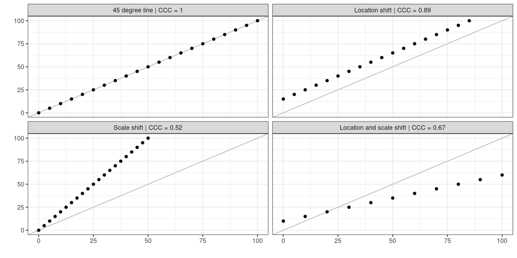

All of the above have a Pearson correlation coefficient of 1.

# Next Lecture

We will go through several examples to practice data splitting, cross-validation, and model evaluation.

# Thanks!

**Questions? Comments?**

Slides made with [Quarto](https://quarto.org)